# Biosignals2: interim summary

Block effects and FaceReader vs ECG agreement

29 October 2026

```r
# ── Blocks ───────────────────────────────────────────────────────────────────
BLOCKS       <- c("baseline", "neg_induction", "neg_recovery", "pos_induction", "pos_recovery")
BLOCK_LABELS <- c("Baseline", "Neg induction", "Neg recovery", "Pos induction", "Pos recovery")
BLOCK_COLS   <- setNames(c("#888888", "#D9653B", "#F0B49A", "#3F7FB5", "#A8C4D8"), BLOCK_LABELS)

# Any block spelling used in this project -> one of BLOCKS. Recovery is tested first because
# "post_negative_induction_recovery" contains both words.
to_block <- function(x) {
  x <- tolower(str_replace_all(str_remove(str_trim(as.character(x)), "\\(\\d+\\)$"), "[ -]+", "_"))
  neg <- str_detect(x, "^neg|_neg|negative"); pos <- str_detect(x, "^pos|_pos|positive")
  rec <- str_detect(x, "recov|reconv");      ind <- str_detect(x, "induc")
  case_when(str_detect(x, "baseline") ~ "baseline",
            neg & rec ~ "neg_recovery",  pos & rec ~ "pos_recovery",
            neg & ind ~ "neg_induction", pos & ind ~ "pos_induction",
            TRUE ~ NA_character_)
}
block_factor <- function(b) factor(BLOCK_LABELS[match(b, BLOCKS)], levels = BLOCK_LABELS)

norm_pid <- function(x) toupper(str_trim(as.character(x)))
keep_pids <- function(d) d |> filter(participant_keep(pid, INCLUDE_PILOTS))
num <- function(x) suppressWarnings(as.numeric(str_replace(str_trim(as.character(x)), ",", ".")))
`%||%` <- function(a, b) if (is.null(a)) b else a

# Every loader returns a long tibble: pid, block (factor), measure, value.
# A loader that can't find its data returns an empty tibble with attr "note".
empty_long <- function(note) structure(tibble(pid = character(), block = factor(levels = BLOCK_LABELS),
                                              measure = character(), value = numeric()), note = note)
safely_load <- function(expr, what) tryCatch(expr, error = function(e)
  empty_long(paste0(what, ": could not be read (", conditionMessage(e), ")")))
show_note <- function(d) if (!is.null(attr(d, "note"))) cat("> **Not shown:** ", attr(d, "note"), "\n\n", sep = "")

# ── Statistics ───────────────────────────────────────────────────────────────
# Linear mixed model per measure: value ~ block + (1 | participant). Reports the omnibus block
# effect (Satterthwaite F test) and three planned contrasts. Blocks a measure doesn't have are
# simply left out of its model.
CONTRASTS <- list(`Neg ind - Baseline` = c(`Neg induction` = 1, Baseline = -1),
                  `Pos ind - Baseline` = c(`Pos induction` = 1, Baseline = -1),
                  `Pos ind - Neg ind`  = c(`Pos induction` = 1, `Neg induction` = -1))

block_test <- function(d) {
  d <- d |> filter(!is.na(value)) |> mutate(block = droplevels(block))
  out <- tibble(n = n_distinct(d$pid), F = NA_real_, df = NA_character_, p = NA_real_)
  for (k in names(CONTRASTS)) out[[k]] <- NA_real_
  for (k in names(CONTRASTS)) out[[paste0(k, " p")]] <- NA_real_
  if (out$n < 3 || nlevels(d$block) < 2) return(out)
  m <- tryCatch(suppressMessages(lmer(value ~ block + (1 | pid), data = d)), error = function(e) NULL)
  if (is.null(m)) return(out)
  a <- anova(m)
  out$F <- a$`F value`[1]; out$df <- sprintf("%d, %.1f", a$NumDF[1], a$DenDF[1]); out$p <- a$`Pr(>F)`[1]
  emm <- emmeans(m, ~ block)
  lv  <- levels(d$block)
  for (k in names(CONTRASTS)) {
    w <- CONTRASTS[[k]]
    if (!all(names(w) %in% lv)) next
    v <- setNames(rep(0, length(lv)), lv); v[names(w)] <- w
    s <- summary(contrast(emm, method = setNames(list(unname(v)), k)))
    out[[k]] <- s$estimate; out[[paste0(k, " p")]] <- s$p.value
  }
  out
}

block_means <- function(d) d |>
  group_by(measure, block) |>
  summarise(m = mean(value, na.rm = TRUE), s = sd(value, na.rm = TRUE), .groups = "drop") |>
  mutate(txt = ifelse(is.na(s), sprintf("%.2f", m), sprintf("%.2f (%.2f)", m, s))) |>
  select(measure, block, txt) |>
  pivot_wider(names_from = block, values_from = txt)

test_table <- function(d) {
  if (!nrow(d)) return(tibble())
  d |> group_by(measure) |> group_modify(~ block_test(.x)) |> ungroup()
}

fmt_p   <- function(p) ifelse(is.na(p), "–", ifelse(p < .001, "<.001", sprintf("%.3f", p)))
fmt_est <- function(e, p) ifelse(is.na(e), "–", sprintf("%+.2f%s", e,
                                 ifelse(p < .05, " *", "")))
pretty_tests <- function(t) {
  if (!nrow(t)) return(t)
  out <- t |> transmute(Measure = measure, N = n,
                        `Block effect` = ifelse(is.na(F), "–", sprintf("F(%s) = %.2f", df, F)),
                        p = fmt_p(p))
  for (k in names(CONTRASTS)) out[[k]] <- fmt_est(t[[k]], t[[paste0(k, " p")]])
  out
}

# ── Plot: one panel per measure, thin line per participant, mean ± SE ────────
plot_blocks <- function(d, ncol = 3, ylab = NULL) {
  s <- d |> group_by(measure, block) |>
    summarise(m = mean(value, na.rm = TRUE), se = sd(value, na.rm = TRUE) / sqrt(sum(!is.na(value))),
              .groups = "drop")
  ggplot(d, aes(block, value)) +
    geom_line(aes(group = pid), colour = "grey80", linewidth = 0.4) +
    geom_point(colour = "grey70", size = 1) +
    geom_errorbar(data = s, aes(y = m, ymin = m - se, ymax = m + se), width = 0.15, colour = "grey20") +
    geom_point(data = s, aes(y = m, fill = block), shape = 21, size = 3.2, colour = "grey20") +
    scale_fill_manual(values = BLOCK_COLS, guide = "none") +
    facet_wrap(~ measure, scales = "free_y", ncol = ncol) +
    labs(x = NULL, y = ylab) +
    theme_minimal(base_size = 11) +
    theme(axis.text.x = element_text(angle = 30, hjust = 1), panel.grid.minor = element_blank(),
          strip.text = element_text(face = "bold"))
}
```

```r
order_counts <- NULL   # how many participants did the negative / positive block first
# Block-level state ratings (1–7), given at the END of each block (baseline: after the
# 3-min fixation). Not the per-video ratings.
ratings <- safely_load({
  f <- file.path(get0("COMBINED_PSYCHO_DIR", ifnotfound = file.path(SERVER_ROOT, "clean_combined_data", "psychopy")),
                 "biosignals2_selfreport_ratings.csv")
  if (!file.exists(f)) empty_long("biosignals2_selfreport_ratings.csv not found (knit 01_data_cleaning.Rmd).") else
    read_csv(f, show_col_types = FALSE) |>
      (\(d) { order_counts <<- if ("conditionOrder" %in% names(d)) d |> filter(participant_keep(participant_id, INCLUDE_PILOTS)) |>
                 distinct(participant_id, conditionOrder) |> count(conditionOrder) else NULL; d })() |>
      transmute(pid = norm_pid(participant_id), block = to_block(condition),
                Valence = block_end_valence, Arousal = block_end_arousal) |>
      filter(!is.na(block)) |>
      group_by(pid, block) |> summarise(across(c(Valence, Arousal), ~ first(na.omit(.x))), .groups = "drop") |>
      pivot_longer(c(Valence, Arousal), names_to = "measure", values_to = "value") |>
      mutate(block = block_factor(block)) |> keep_pids()
}, "Self-report")
```

```r
# Ledalab continuous decomposition (CDA), one value per block, read straight from Ledalab's
# event-related (ERA) export: ledalab/<id>_era.txt (response window 0–180 s, threshold 0.05 µS).
#   CDA.SCR   = mean phasic driver in the window (primary measure)
#   CDA.nSCR  = number of SCRs in the window
#   CDA.Tonic = mean tonic level in the window
# Event numbers -> blocks via event_onsets/blocks/nid_map_biopac_ledalab.txt (the BIOPAC events
# imported into Ledalab). Read directly, so 05 doesn't need re-knitting first. A participant with
# several ERA files (e.g. different capitalisation) uses the newest; empty or unreadable files
# are skipped and listed.
SCR_MEASURES <- c(`SCR: mean phasic driver (µS)` = "CDA.SCR",
                  `SCR: count (n)`              = "CDA.nSCR",
                  `SCR: tonic level (µS)`       = "CDA.Tonic")
scr_notes <- character(0)
scr <- safely_load({
  era <- list.files(LEDALAB_RESULTS_DIR, pattern = "_era\\.txt$", full.names = TRUE, ignore.case = TRUE)
  if (!length(era)) stop("no Ledalab ERA files (<id>_era.txt) in the ledalab folder")
  map_path <- file.path(BLOCK_ONSETS_DIR, c("nid_map_biopac_ledalab.txt", "nid_map_psychopy_ledalab.txt"))
  map_path <- map_path[file.exists(map_path)][1]
  if (is.na(map_path)) stop("no nid_map_biopac_ledalab.txt in event_onsets/blocks (run ledalab/01_create_ledalab_events_biopac.py)")
  nid <- read_tsv(map_path, show_col_types = FALSE)
  files <- tibble(path = era, pid = norm_pid(str_extract(basename(era), "^[^_]+")), mtime = file.mtime(era),
                  size = file.size(era)) |>
    filter(participant_keep(pid, INCLUDE_PILOTS))
  for (k in which(files$size == 0)) scr_notes <- c(scr_notes, paste(files$pid[k], "– ERA file is empty (re-run Ledalab)"))
  files <- files |> filter(size > 0) |> group_by(pid) |> slice_max(mtime, n = 1, with_ties = FALSE) |> ungroup()
  map_dfr(seq_len(nrow(files)), function(k) {
    e <- tryCatch(read.table(files$path[k], header = TRUE, sep = "\t", stringsAsFactors = FALSE, check.names = FALSE),
                  error = function(err) { scr_notes <<- c(scr_notes, paste(files$pid[k], "– ERA file unreadable:", conditionMessage(err))); NULL })
    if (is.null(e)) return(tibble())
    names(e)[tolower(names(e)) == "event.nid"] <- "nid"
    if (!"nid" %in% names(e)) { scr_notes <<- c(scr_notes, paste(files$pid[k], "– ERA file has no Event.NID column")); return(tibble()) }
    # keep only the columns used (other columns, e.g. Event.Name, differ in type between files)
    e |> select(nid, any_of(unname(SCR_MEASURES))) |> mutate(nid = as.integer(nid), pid = files$pid[k]) |>
      left_join(nid, by = "nid") |> mutate(block = to_block(condition))
  }) |>
    filter(!is.na(block)) |>
    select(pid, block, any_of(unname(SCR_MEASURES))) |>
    pivot_longer(-c(pid, block), names_to = "measure", values_to = "value") |>
    group_by(pid, block, measure) |> summarise(value = mean(value, na.rm = TRUE), .groups = "drop") |>
    mutate(measure = names(SCR_MEASURES)[match(measure, SCR_MEASURES)], block = block_factor(block),
           value = ifelse(is.nan(value), NA, value))
}, "Ledalab SCR")
```

```r
# Kubios readers (same logic as generate_qc_report.R). The stream (ECG vs FaceReader) is told
# apart by the name of the file Kubios analysed. Per participant and stream the newest
# report is used; the batch summary (KubiosHRVresults*.csv, samples S1..S5 in
# Kubios_Samples.csv order) only when there is no report.
kubios_stream <- function(name) {
  n <- tolower(basename(as.character(name)))
  case_when(str_detect(n, "facereader|heart beat log") ~ "facereader",
            str_detect(n, "webcam") ~ "webcam", TRUE ~ "ecg")
}
kub_blank <- function(x) x[!is.na(x) & nzchar(x)]

read_kubios_report <- function(f) {
  L <- tryCatch(read_lines(f), error = function(e) character(0))
  h <- which(str_detect(L, fixed("RR Interval Samples Selected for Analysis")))[1]
  if (is.na(h)) return(tibble())
  labels <- kub_blank(str_trim(str_split(L[h + 1], ",")[[1]][-1]))
  n <- length(labels); if (!n) return(tibble())
  val <- function(pattern) {
    i <- which(str_detect(L, pattern))[1]
    x <- if (is.na(i)) rep(NA_real_, n) else num(kub_blank(str_trim(str_split(L[i], ",")[[1]][-1])))
    length(x) <- n; x
  }
  tibble(pid = norm_pid(str_extract(basename(f), "^[^_]+")), stream = kubios_stream(f),
         block = to_block(labels), n_beats = val(fixed("Beats total:")),
         HR = val(fixed("Mean HR (beats/min):")), RMSSD = val(fixed("RMSSD (ms):")),
         SDNN = val(fixed("SDNN (ms):")),
         corrected = val(regex("^\\s*(Beats?|Artefacts?|Artifacts?) corrected", ignore_case = TRUE)),
         mtime = file.mtime(f), from = "report", file = basename(f))
}
read_kubios_batch <- function(f) {
  # Header row = the first line containing FileName (usually line 3, after "sep=," and a title)
  hdr <- tryCatch(which(grepl("FileName", readLines(f, n = 20, warn = FALSE), fixed = TRUE))[1], error = function(e) NA)
  if (is.na(hdr)) return(tibble())
  raw <- tryCatch(read_csv(f, skip = hdr - 1, col_types = cols(.default = col_character()),
                           name_repair = "unique_quiet", show_col_types = FALSE), error = function(e) NULL)
  if (is.null(raw) || !"FileName" %in% names(raw)) return(tibble())
  raw <- raw |> filter(!is.na(FileName), nzchar(str_trim(FileName)))
  # Column for sample i whose name (after "S<i>_") starts with the metric, e.g. "S1_Mean HR (bpm)"
  # or "S1_Mean HR (beats/min)" - the unit text differs between Kubios versions
  col <- function(i, pattern) {
    k <- names(raw)[startsWith(names(raw), paste0("S", i, "_")) &
                    str_detect(sub("^S\\d+_", "", names(raw)), regex(pattern, ignore_case = TRUE))][1]
    if (is.na(k)) NA_real_ else num(raw[[k]])
  }
  fname <- basename(gsub("\\\\", "/", raw$FileName))   # FileName may be a full Windows path
  map_dfr(seq_along(BLOCKS), function(i) tibble(
    pid = norm_pid(str_extract(fname, "^[^_.]+")), stream = kubios_stream(fname),
    block = BLOCKS[i], n_beats = NA_real_, HR = col(i, "^Mean HR"), RMSSD = col(i, "^RMSSD"),
    SDNN = col(i, "^SDNN"), corrected = col(i, "^(Beats?|Artefacts?|Artifacts?) corrected"),
    mtime = file.mtime(f), from = "batch", file = basename(f)))
}

kubios <- safely_load({
  # Kubios folders, plus clean_combined_data (where biosignals2_KubiosHRVresults.csv, the batch
  # summary 06_build_ml_dataset.R reads, lives). Batch summaries: any *KubiosHRVresults*.csv.
  dirs <- unique(c(KUBIOS_DIR, file.path(KUBIOS_DIR, "kubios"), FR_DIR, file.path(FR_DIR, "kubios"),
                   get0("COMBINED_DATA_DIR", ifnotfound = file.path(SERVER_ROOT, "clean_combined_data"))))
  dirs <- dirs[dir.exists(dirs)]
  rep_files   <- unlist(map(dirs, ~ list.files(.x, "_hrv\\.csv$", full.names = TRUE, ignore.case = TRUE)))
  batch_files <- unlist(map(dirs, ~ list.files(.x, "KubiosHRVresults.*\\.csv$", full.names = TRUE, ignore.case = TRUE)))
  reps  <- map_dfr(unique(rep_files), read_kubios_report)
  batch <- map_dfr(unique(batch_files), read_kubios_batch)
  pick_newest <- function(d) if (!nrow(d)) d else d |> group_by(pid, stream) |> filter(mtime == max(mtime)) |>
    group_by(pid, stream, block) |> slice_tail(n = 1) |> ungroup()
  reps <- pick_newest(reps); batch <- pick_newest(batch)
  k <- bind_rows(reps, if (nrow(batch)) anti_join(batch, distinct(reps, pid, stream), by = c("pid", "stream")))
  if (!nrow(k)) stop("no Kubios reports or batch summaries found")
  k <- k |> filter(stream %in% c("ecg", "facereader"), !is.na(block), !is.na(HR)) |>
    mutate(pid = norm_pid(pid)) |> keep_pids()
  # Console only (not in the HTML): which Kubios file each participant's values came from
  src <- k |> distinct(pid, stream, from, file) |> arrange(stream, pid)
  cat("Kubios files used:\n", paste0("  ", src$stream, "  ", src$pid, "  ", src$from, ": ", src$file, "\n"),
      sep = "", file = stderr())   # to the R console / knit log, not the HTML
  k
}, "Kubios")

# Kubios artefact correction per block (before any block is dropped), for section 1.1
kubios_qc <- if (nrow(kubios)) kubios |> select(pid, stream, block, n_beats, corrected) else
  tibble(pid = character(), stream = character(), block = character(), n_beats = numeric(), corrected = numeric())

# FaceReader blocks with too few beats are unreliable -> dropped everywhere below
fr_low_beats <- if (nrow(kubios)) kubios |> filter(stream == "facereader", !is.na(n_beats), n_beats < MIN_BLOCK_BEATS) else tibble()
if (nrow(kubios)) kubios <- kubios |> anti_join(fr_low_beats, by = c("pid", "stream", "block"))

hr_long <- function(s) {
  if (!nrow(kubios)) return(empty_long(attr(kubios, "note")))
  d <- kubios |> filter(stream == s)
  if (!nrow(d)) return(empty_long(paste0("no Kubios results for the ", ifelse(s == "ecg", "ECG", "FaceReader"), " beats yet.")))
  d |> select(pid, block, HR, RMSSD, SDNN) |>
    pivot_longer(c(HR, RMSSD, SDNN), names_to = "measure", values_to = "value") |>
    mutate(measure = recode(measure, HR = "HR (bpm)", RMSSD = "RMSSD (ms)", SDNN = "SDNN (ms)"),
           block = block_factor(block))
}
ecg_hr <- hr_long("ecg")
fr_hr  <- hr_long("facereader")
```

```r
# FaceReader action units per block, from the detailed log (<id>_detailed.txt/.xlsx).
# Block windows: the FaceReader row of facereader/Kubios_Samples.csv (kubios/002), i.e. the SAME
# windows, on FaceReader's own clock, that Kubios used for FaceReader HR/HRV. The detailed log and
# the heart beat log come from the same FaceReader run, so they share that clock; this is checked
# by comparing the video named in both logs.
# Frames where FaceReader found no face (FIND_FAILED / FIT_FAILED) are left out; a block with less
# than MIN_FACE_VALID of its frames with a face is dropped.
au_letters <- c(NotActive = 0, A = 0.11, B = 0.35, C = 0.62, D = 0.85, E = 0.97)
parse_au <- function(x) { v <- num(x); i <- x %in% names(au_letters); v[i] <- au_letters[x[i]]; v }
fr_time <- function(x) {
  x <- str_replace(as.character(x), ",", "."); p <- str_split_fixed(x, ":", 3)
  v <- num(x)   # plain number: seconds, or an Excel day fraction (< 1)
  ifelse(str_detect(x, ":"), num(p[, 1]) * 3600 + num(p[, 2]) * 60 + num(p[, 3]), ifelse(v < 1, v * 86400, v))
}

# Header row (first cell == header_key) and the metadata rows above it
read_fr_log <- function(path, header_key) {
  if (str_detect(path, regex("\\.xlsx?$", ignore_case = TRUE))) {
    g <- as.data.frame(readxl::read_excel(path, sheet = 1, col_names = FALSE, col_types = "text",
                                          .name_repair = "minimal"), stringsAsFactors = FALSE)
    h <- which(str_trim(g[[1]]) == header_key)[1]; if (is.na(h)) return(NULL)
    meta <- g[seq_len(h - 1), 1:2, drop = FALSE]
    body <- g[-seq_len(h), , drop = FALSE]; names(body) <- str_trim(as.character(unlist(g[h, ])))
  } else {
    L <- sub("^", "", readLines(path, warn = FALSE, encoding = "UTF-8"))
    h <- which(str_trim(str_extract(L, "^[^\t]*")) == header_key)[1]; if (is.na(h)) return(NULL)
    meta <- as.data.frame(str_split_fixed(L[seq_len(h - 1)], "\t", 3)[, 1:2, drop = FALSE])
    body <- read.delim(text = L[h:length(L)], sep = "\t", colClasses = "character", check.names = FALSE,
                       quote = "", na.strings = character(0), strip.white = TRUE)
  }
  video <- meta[[2]][str_detect(tolower(str_trim(meta[[1]])), "^file ?name")][1]
  list(body = body, video = tolower(basename(gsub("\\\\", "/", str_trim(video %||% NA_character_)))))
}

read_fr_windows <- function() {
  f <- file.path(FR_DIR, "Kubios_Samples.csv")
  if (!file.exists(f)) return(tibble())
  L <- read_lines(f)[-1]; L <- L[nzchar(str_trim(L))]
  map_dfr(str_split(L, ","), function(p) {
    tr <- matrix(p[-(1:2)][seq_len(3 * floor((length(p) - 2) / 3))], ncol = 3, byrow = TRUE)
    tibble(file = p[1], block = to_block(tr[, 1]), start = num(tr[, 2]), end = num(tr[, 3]))
  }) |> mutate(pid = norm_pid(str_extract(basename(file), "^[^_]+")),
               is_log = str_detect(tolower(file), "heart beat log")) |>
    filter(!is.na(block), !is.na(start), !is.na(end))
}

au_notes <- character(0)
aus <- safely_load({
  wins <- read_fr_windows()
  if (!nrow(wins)) stop("no facereader/Kubios_Samples.csv (run kubios/002_create_kubios_samples_video.py)")
  logs <- list.files(FR_DIR, "_detailed\\.(txt|xlsx)$", full.names = TRUE, ignore.case = TRUE)
  logs <- logs[!startsWith(basename(logs), "~$")]
  logs <- logs[participant_keep(str_extract(basename(logs), "^[^_]+"), INCLUDE_PILOTS)]
  logs <- logs[!duplicated(norm_pid(str_extract(basename(logs), "^[^_]+")))]   # .txt before .xlsx
  if (!length(logs)) stop("no FaceReader detailed logs (<id>_detailed.txt/.xlsx)")
  out <- map_dfr(logs, function(path) {
    pid <- norm_pid(str_extract(basename(path), "^[^_]+"))
    w <- wins |> filter(pid == !!pid) |> arrange(desc(is_log))   # heart beat log row first (no time shift)
    w <- w |> filter(file == first(file))
    if (!nrow(w)) { au_notes <<- c(au_notes, paste(pid, "– no block windows in Kubios_Samples.csv")); return(tibble()) }
    lg <- read_fr_log(path, "Video Time")
    if (is.null(lg)) { au_notes <<- c(au_notes, paste(pid, "– detailed log has no 'Video Time' header")); return(tibble()) }
    hb <- list.files(FR_DIR, "heart beat log\\.(txt|xlsx)$", full.names = TRUE, ignore.case = TRUE)
    hb <- hb[norm_pid(str_extract(basename(hb), "^[^_]+")) == pid]
    hb_video <- if (length(hb)) tryCatch(read_fr_log(hb[1], "Time")$video, error = function(e) NA) else NA
    if (!is.na(hb_video) && !is.na(lg$video) && hb_video != lg$video) {
      au_notes <<- c(au_notes, paste0(pid, " – detailed log and heart beat log come from different videos ",
                                      "(re-export both from the same FaceReader run)")); return(tibble())
    }
    b <- lg$body
    au_cols <- names(b)[str_detect(names(b), "^Action Unit \\d+ - ") & !str_detect(names(b), " - (Left|Right) - ")]
    if (!length(au_cols)) { au_notes <<- c(au_notes, paste(pid, "– no action unit columns in the export")); return(tibble()) }
    t <- fr_time(b[["Video Time"]])
    valid <- if ("Neutral" %in% names(b)) !is.na(num(b$Neutral)) else !is.na(num(b[[au_cols[1]]]))
    au <- as.data.frame(lapply(b[au_cols], parse_au)); names(au) <- au_cols
    map_dfr(seq_len(nrow(w)), function(i) {
      inb <- !is.na(t) & t >= w$start[i] & t < w$end[i]
      ok  <- inb & valid
      prop <- if (any(inb)) mean(valid[inb]) else 0
      tibble(pid = pid, block = w$block[i], prop_valid = prop, measure = au_cols,
             value = if (prop >= MIN_FACE_VALID) colMeans(au[ok, , drop = FALSE], na.rm = TRUE) else NA_real_)
    })
  })
  if (!nrow(out)) stop("no usable FaceReader detailed logs")
  out |> mutate(au = sprintf("AU%02d", as.integer(str_match(measure, "^Action Unit (\\d+)")[, 2])),
                au_name = str_match(measure, "^Action Unit \\d+ - (.+)$")[, 2],
                measure = paste(au, au_name), block = block_factor(block),
                value = ifelse(is.nan(value), NA, value))
}, "FaceReader action units")
face_valid <- if (nrow(aus)) aus |> distinct(pid, block, prop_valid) else tibble()

# FaceReader heart-rate coverage per block, from the heart beat log: the share of the block
# spanned by consecutive beats no more than MAX_IBI_GAP_S apart. Longer gaps are time with no
# heart-rate signal: face lost, FaceReader's ~8.5-s recalibration after it finds the face again,
# or beats it could not detect. Same block windows as Kubios and the AUs.
hr_cov <- tryCatch({
  wins <- read_fr_windows() |> filter(is_log)
  hb <- list.files(FR_DIR, "heart beat log\\.(txt|xlsx)$", full.names = TRUE, ignore.case = TRUE)
  hb <- hb[!startsWith(basename(hb), "~$")]
  hb <- hb[participant_keep(str_extract(basename(hb), "^[^_]+"), INCLUDE_PILOTS)]
  hb <- hb[!duplicated(norm_pid(str_extract(basename(hb), "^[^_]+")))]
  map_dfr(hb, function(path) {
    pid <- norm_pid(str_extract(basename(path), "^[^_]+"))
    w <- wins |> filter(pid == !!pid, tolower(basename(file)) == tolower(basename(path)))
    if (!nrow(w)) w <- wins |> filter(pid == !!pid) |> filter(file == first(file))
    lg <- read_fr_log(path, "Time")
    if (!nrow(w) || is.null(lg)) return(tibble())
    t <- sort(fr_time(lg$body[[1]])); t <- t[!is.na(t)]
    s <- head(t, -1); e <- t[-1]; ok <- (e - s) <= MAX_IBI_GAP_S
    tibble(pid = pid, block = w$block, prop_hr = map2_dbl(w$start, w$end, function(a, b)
      if (length(t) < 2) 0 else sum(pmax(0, pmin(e, b) - pmax(s, a))[ok]) / (b - a)))
  })
}, error = function(e) tibble())

fr_missing <- full_join(
  if (nrow(face_valid)) face_valid |> transmute(pid, block = as.character(block), face = 100 * (1 - prop_valid)) else tibble(pid = character(), block = character(), face = numeric()),
  if (nrow(hr_cov)) hr_cov |> transmute(pid, block = BLOCK_LABELS[match(block, BLOCKS)], hr = 100 * (1 - pmin(prop_hr, 1))) else tibble(pid = character(), block = character(), hr = numeric()),
  by = c("pid", "block")) |>
  full_join(kubios_qc |> filter(stream == "facereader") |>
              transmute(pid, block = BLOCK_LABELS[match(block, BLOCKS)], kub = corrected), by = c("pid", "block")) |>
  filter(!is.na(block)) |> mutate(block = factor(block, levels = BLOCK_LABELS))
ecg_corrected <- kubios_qc |> filter(stream == "ecg", pid %in% fr_missing$pid) |> pull(corrected)
```

```r
# One anonymous code per participant, used in every table below: P01, P02, ...
# The code -> ID key is stored only on Box (ID_KEY_PATH, next to the other data), never in this
# repository. Codes are NOT derived from IDs: participants who are new at a knit get the next
# free numbers in a RANDOM order, so nothing in this code (public on GitHub) can rebuild the key.
# Codes are kept from knit to knit and never reused. (Only the batch a participant was added in
# can be told from the number, e.g. P11+ joined after the first knit.)
ID_KEY_PATH <- file.path(SERVER_ROOT, "private", "interim_report_id_key.csv")
# Earlier location: read from there once if the key hasn't been moved yet, so codes are kept
ID_KEY_OLD_PATH <- file.path(SERVER_ROOT, "clean_combined_data", "interim_report_private", "interim_report_id_key.csv")
all_pids <- sort(unique(c(ratings$pid, scr$pid, ecg_hr$pid, fr_hr$pid, aus$pid, fr_missing$pid)))
if (ANONYMISE_IDS) {
  # The same key is used by 08_combine_timeseries.R (analysis/id_key.R): one code per person
  # everywhere. New participants are added and the key is saved here, before anything uses it.
  source(file.path(analysis_dir, "id_key.R"), local = TRUE)
  if (!file.exists(ID_KEY_PATH) && file.exists(ID_KEY_OLD_PATH)) {   # one-off move from the old place
    dir.create(dirname(ID_KEY_PATH), showWarnings = FALSE, recursive = TRUE)
    file.copy(ID_KEY_OLD_PATH, ID_KEY_PATH)
  }
  pid_code <- id_key_codes(all_pids, ID_KEY_PATH)
} else {
  pid_code <- setNames(all_pids, all_pids)
}
```

## Summary

Main-study participants with data so far: self-report **19**, SCR **19**, ECG HR/HRV **17**, FaceReader HR/HRV **8**, FaceReader action units **7**. The sample is still small, so every test below is **descriptive and exploratory**: it shows where the data are heading, not confirmed effects.

**How the tests work.** For each measure we fit a linear mixed model `value ~ block + (1 | participant)`. The *block effect* is the omnibus F test across the five blocks. The three planned contrasts are estimated differences in the measure’s own units (`*` = p < .05, uncorrected): negative induction vs baseline, positive induction vs baseline, and positive vs negative induction. The FaceReader action units are shown descriptively only (plots in section 2.5): with ~20 AUs and this few participants, tests would mostly show noise.

```r
all_main <- bind_rows(
  ratings |> mutate(measure = paste("Self-report", tolower(measure)), domain = "1"),
  scr     |> mutate(domain = "2"),
  ecg_hr  |> mutate(measure = paste("ECG", measure), domain = "3"),
  fr_hr   |> mutate(measure = paste("FaceReader", measure), domain = "4"))
if (nrow(all_main)) {
  ord <- all_main |> distinct(domain, measure) |> arrange(domain)
  tt  <- test_table(all_main |> select(-domain))
  pretty_tests(tt) |>
    left_join(block_means(all_main), by = c(Measure = "measure")) |>
    arrange(match(Measure, ord$measure)) |>
    select(Measure, N, all_of(intersect(BLOCK_LABELS, names(block_means(all_main)))), everything()) |>
    kable(caption = "Block means (SD) and block tests. FaceReader action units: plots only, in section 2.5.",
          align = "l")
} else cat("No data available yet.\n")
```

Block means (SD) and block tests. FaceReader action units: plots only, in section 2.5.

| Measure | N | Baseline | Neg induction | Neg recovery | Pos induction | Pos recovery | Block effect | p | Neg ind - Baseline | Pos ind - Baseline | Pos ind - Neg ind |
| --- | --- | --- | --- | --- | --- | --- | --- | --- | --- | --- | --- |
| Self-report valence | 19 | 4.21 (1.23) | 2.21 (0.92) | 3.58 (0.84) | 5.16 (0.69) | 4.37 (0.96) | F(4, 72.0) = 46.45 | <.001 | -2.00 * | +0.95 * | +2.95 * |
| Self-report arousal | 19 | 3.84 (1.54) | 4.95 (1.27) | 3.84 (1.34) | 4.05 (1.31) | 3.26 (1.24) | F(4, 72.0) = 8.28 | <.001 | +1.11 * | +0.21 | -0.89 * |
| SCR: mean phasic driver (µS) | 19 | 0.03 (0.04) | 0.05 (0.06) | 0.03 (0.03) | 0.03 (0.02) | 0.02 (0.02) | F(4, 72.0) = 3.27 | 0.016 | +0.03 * | +0.01 | -0.02 * |
| SCR: tonic level (µS) | 19 | 9.81 (5.96) | 10.78 (6.58) | 10.30 (6.45) | 10.76 (6.75) | 10.27 (6.44) | F(4, 72.0) = 3.20 | 0.018 | +0.97 * | +0.95 * | -0.02 |
| SCR: count (n) | 19 | 35.79 (37.39) | 52.89 (32.55) | 40.84 (33.90) | 50.68 (27.33) | 40.47 (35.24) | F(4, 72.0) = 2.60 | 0.043 | +17.11 * | +14.89 * | -2.21 |
| ECG HR (bpm) | 17 | 81.56 (10.89) | 82.80 (9.98) | 82.97 (11.69) | 81.35 (9.89) | 83.14 (10.30) | F(4, 64.0) = 1.28 | 0.287 | +1.23 | -0.21 | -1.45 |
| ECG RMSSD (ms) | 17 | 33.93 (24.13) | 33.71 (20.48) | 32.05 (21.95) | 29.63 (19.33) | 27.99 (20.59) | F(4, 64.0) = 1.86 | 0.129 | -0.21 | -4.30 | -4.09 |
| ECG SDNN (ms) | 17 | 38.18 (16.91) | 39.49 (17.46) | 39.41 (18.01) | 33.78 (12.34) | 34.64 (15.10) | F(4, 64.0) = 2.28 | 0.071 | +1.31 | -4.40 | -5.71 * |
| FaceReader HR (bpm) | 8 | 80.76 (13.59) | 82.25 (10.87) | 82.63 (14.30) | 80.65 (12.40) | 81.77 (11.38) | F(4, 28.0) = 0.92 | 0.466 | +1.49 | -0.11 | -1.60 |
| FaceReader RMSSD (ms) | 8 | 48.56 (31.50) | 47.04 (16.44) | 43.39 (25.73) | 49.36 (18.14) | 42.33 (14.50) | F(4, 28.0) = 0.73 | 0.576 | -1.52 | +0.80 | +2.32 |
| FaceReader SDNN (ms) | 8 | 43.53 (20.93) | 41.68 (15.32) | 42.13 (22.09) | 40.13 (10.59) | 37.45 (9.96) | F(4, 28.0) = 0.67 | 0.616 | -1.85 | -3.41 | -1.56 |

**FaceReader missing data (section 1.1):** across 8 participants’ blocks, face not found in 0% (range 0–6%) of video frames; no heart-rate signal for 7% (range 0–29%) of block time; Kubios corrected 5% (range 0–37%) of FaceReader beats as noise (ECG: 0.3%).

## 1. Data available per participant

```r
has <- function(d) if (nrow(d)) d |> filter(!is.na(value)) |> group_by(pid) |> summarise(n = n_distinct(block)) else tibble(pid = character(), n = integer())
avail <- tibble(pid = all_pids) |>
  left_join(has(ratings) |> rename(`Self-report` = n), by = "pid") |>
  left_join(has(scr)     |> rename(SCR = n), by = "pid") |>
  left_join(has(ecg_hr)  |> rename(`ECG HR/HRV` = n), by = "pid") |>
  left_join(has(fr_hr)   |> rename(`FaceReader HR/HRV` = n), by = "pid") |>
  left_join(has(aus)     |> rename(`FaceReader AUs` = n), by = "pid") |>
  mutate(across(-pid, ~ ifelse(is.na(.x), "–", paste0(.x, "/5"))), Participant = pid_code[pid]) |>
  select(Participant, everything(), -pid) |> arrange(Participant)
if (nrow(avail)) kable(avail, caption = "Blocks with data (out of 5) per participant and source") else cat("No data yet.\n")
```

Blocks with data (out of 5) per participant and source

| Participant | Self-report | SCR | ECG HR/HRV | FaceReader HR/HRV | FaceReader AUs |
| --- | --- | --- | --- | --- | --- |
| P02 | 5/5 | 5/5 | 5/5 | 5/5 | 5/5 |
| P03 | 5/5 | 5/5 | 5/5 | – | – |
| P04 | 5/5 | 5/5 | 5/5 | 5/5 | 5/5 |
| P05 | 5/5 | 5/5 | 5/5 | 5/5 | 5/5 |
| P06 | 5/5 | 5/5 | 5/5 | 5/5 | 5/5 |
| P07 | 5/5 | 5/5 | 5/5 | 5/5 | 5/5 |
| P08 | 5/5 | 5/5 | 5/5 | 5/5 | 5/5 |
| P09 | 5/5 | 5/5 | 5/5 | 5/5 | 5/5 |
| P10 | 5/5 | 5/5 | 5/5 | 5/5 | – |
| P12 | 5/5 | – | – | – | – |
| P13 | 5/5 | 5/5 | 5/5 | – | – |
| P14 | – | 5/5 | 5/5 | – | – |
| P15 | 5/5 | 5/5 | 5/5 | – | – |
| P16 | 5/5 | 5/5 | 5/5 | – | – |
| P17 | 5/5 | 5/5 | 5/5 | – | – |
| P18 | 5/5 | 5/5 | 5/5 | – | – |
| P19 | 5/5 | 5/5 | 5/5 | – | – |
| P20 | 5/5 | 5/5 | – | – | – |
| P21 | 5/5 | 5/5 | – | – | – |
| P22 | 5/5 | 5/5 | 5/5 | – | – |

```r
# Private key on Box (see the ids chunk): every code ever given, its real ID and, for those in
# this report, the same availability as above. Never written inside the repository. If it can't
# be saved the knit stops, because the codes in this report would then be unrecorded.
if (ANONYMISE_IDS) {
  # Codes are already saved (ids chunk); this only adds the availability columns to the key.
  id_key_set_info(avail |> mutate(last_knitted = format(Sys.time(), "%Y-%m-%d %H:%M")), ID_KEY_PATH)
}
# An older version saved the key inside the repository: warn if that file is still there
if (file.exists(file.path(analysis_dir, "07_interim_summary_id_key.csv")))
  message("Delete analysis/07_interim_summary_id_key.csv: the key now lives on Box only.")
if (file.exists(ID_KEY_OLD_PATH) && file.exists(ID_KEY_PATH))
  message("The ID key is now saved in 3_Data/private/. Delete the old copy: ", ID_KEY_OLD_PATH)
```

```r
if (nrow(fr_low_beats))
  cat(sprintf("- FaceReader HR/HRV: %d block(s) dropped for having fewer than %d beats.\n", nrow(fr_low_beats), MIN_BLOCK_BEATS))
if (nrow(face_valid) && any(face_valid$prop_valid < MIN_FACE_VALID))
  cat(sprintf("- FaceReader AUs: %d block(s) dropped for a face in fewer than %.0f%% of frames.\n",
              sum(face_valid$prop_valid < MIN_FACE_VALID), 100 * MIN_FACE_VALID))
for (n in scr_notes) {   # participant notes start with the ID: show its code instead
  id <- sub(" .*", "", n)
  if (id %in% names(pid_code) || grepl("^[A-Za-z]?\\d+$", id)) {
    code <- if (id %in% names(pid_code)) pid_code[[id]] else if (ANONYMISE_IDS) "a participant" else id
    cat("- SCR: ", code, sub("^\\S+", "", n), "\n", sep = "")
  } else cat("- ", n, "\n", sep = "")
}
for (i in seq_along(au_notes)) {   # notes start with the participant ID: show its code instead
  id <- sub(" .*", "", au_notes[i]); code <- if (id %in% names(pid_code)) pid_code[[id]] else if (ANONYMISE_IDS) "a participant" else id
  cat("- FaceReader AUs: ", code, sub("^\\S+", "", au_notes[i]), "\n", sep = "")
}
```

- FaceReader AUs: P10 – no block windows in Kubios_Samples.csv

### 1.1 How much FaceReader data is missing

FaceReader data can be missing for two reasons:

1. **The face isn’t found.** Shown as the percentage of video frames with no face (no expressions or action units for those frames), and the resulting percentage of block time with **no heart-rate signal**: gaps of more than 2 s between detected beats, which includes FaceReader’s ~8.5-s recalibration each time it finds the face again.
2. **Kubios finds the beat-to-beat (RR) data too noisy.** Shown as the percentage of FaceReader’s beats that Kubios corrected as artefacts, with the ECG’s for comparison. Blocks with more than 5% of beats corrected are counted as noisy.

Kubios artefact (noise) correction was set to **Medium** for both the ECG and the FaceReader data. Participants without a FaceReader export aren’t included here (see the table above). Blocks are dropped from the analyses when a face is found in fewer than 50% of frames (action units) or Kubios has fewer than 10 beats (HR/HRV).

FaceReader missing data per block: mean across participants (min–max). Noisy blocks = blocks with more than 5% of beats corrected by Kubios / blocks with Kubios results.

| Block | Participants | Face not found: % of frames | No heart-rate signal: % of block time | Kubios: % of beats corrected | Noisy blocks | ECG: % of beats corrected |
| --- | --- | --- | --- | --- | --- | --- |
| Baseline | 8 | 0.0 (0.0–0.0) | 0.8 (0.0–4.4) | 4.5 (0.0–12.0) | 3 / 8 | 0.2 (0.0–2.0) |
| Neg induction | 8 | 0.8 (0.0–5.7) | 10.4 (0.0–26.6) | 4.5 (0.0–13.0) | 3 / 8 | 0.5 (0.0–2.0) |
| Neg recovery | 8 | 0.5 (0.0–3.4) | 7.7 (0.0–20.2) | 7.0 (0.0–29.0) | 2 / 8 | 0.2 (0.0–2.0) |
| Pos induction | 8 | 0.1 (0.0–0.6) | 9.1 (0.0–28.8) | 8.4 (3.0–37.0) | 2 / 8 | 0.2 (0.0–2.0) |
| Pos recovery | 8 | 0.2 (0.0–1.5) | 4.7 (0.0–21.3) | 1.5 (0.0–6.0) | 1 / 8 | 0.1 (0.0–1.0) |
| All blocks | 8 | 0.3 (0.0–5.7) | 6.6 (0.0–28.8) | 5.2 (0.0–37.0) | 11 / 40 | 0.3 (0.0–2.0) |

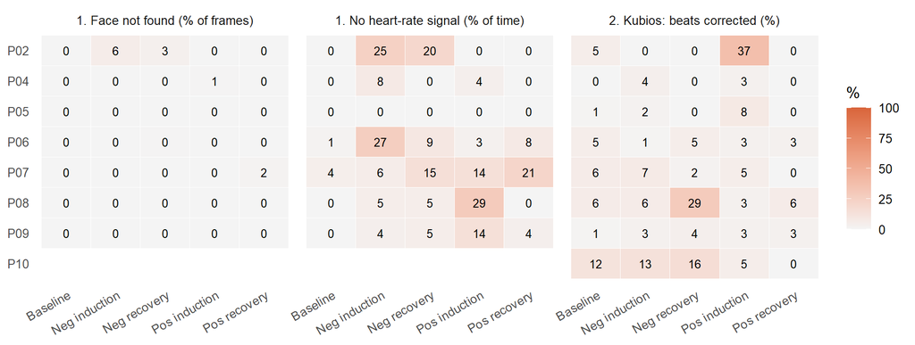

```r
if (!nrow(fr_missing)) {
  cat("> **Not shown:** needs FaceReader detailed logs or heart beat logs plus facereader/Kubios_Samples.csv, or Kubios results for the FaceReader beats.\n")
} else {
  rng <- function(x) { x <- x[!is.na(x)]; if (!length(x)) "–" else sprintf("%.1f (%.1f–%.1f)", mean(x), min(x), max(x)) }
  noisy <- function(x) { x <- x[!is.na(x)]; if (!length(x)) "–" else sprintf("%d / %d", sum(x > FLAG_CORRECTED_PCT), length(x)) }
  ecg_by_block <- kubios_qc |> filter(stream == "ecg", pid %in% fr_missing$pid) |>
    mutate(Block = BLOCK_LABELS[match(block, BLOCKS)])
  ecg_rng <- function(b) rng(if (b == "All blocks") ecg_by_block$corrected else ecg_by_block$corrected[ecg_by_block$Block == b])
  tab <- bind_rows(fr_missing |> group_by(Block = as.character(block)),
                   fr_missing |> mutate(Block = "All blocks") |> group_by(Block)) |>
    summarise(Participants = n_distinct(pid),
              `Face not found: % of frames` = rng(face),
              `No heart-rate signal: % of block time` = rng(hr),
              `Kubios: % of beats corrected` = rng(kub),
              `Noisy blocks` = noisy(kub), .groups = "drop") |>
    mutate(`ECG: % of beats corrected` = map_chr(Block, ecg_rng)) |>
    arrange(match(Block, c(BLOCK_LABELS, "All blocks")))
  print(kable(tab, align = "lcccccc", caption = paste0(
    "FaceReader missing data per block: mean across participants (min–max). Noisy blocks = blocks with more than ",
    FLAG_CORRECTED_PCT, "% of beats corrected by Kubios / blocks with Kubios results.")))

  long <- fr_missing |> pivot_longer(c(face, hr, kub), names_to = "what", values_to = "pct") |>
    filter(!is.na(pct)) |>
    mutate(what = factor(recode(what, face = "1. Face not found (% of frames)", hr = "1. No heart-rate signal (% of time)",
                                kub = "2. Kubios: beats corrected (%)")),
           Participant = factor(pid_code[pid], levels = rev(sort(unique(pid_code[pid])))))
  print(ggplot(long, aes(block, Participant, fill = pct)) +
    geom_tile(colour = "white") + geom_text(aes(label = sprintf("%.0f", pct)), size = 3) +
    scale_fill_gradient(low = "#F4F4F4", high = "#D9653B", limits = c(0, 100), name = "%") +
    facet_wrap(~ what) + labs(x = NULL, y = NULL) + theme_minimal(base_size = 11) +
    theme(axis.text.x = element_text(angle = 30, hjust = 1), panel.grid = element_blank()))
}
```

## 2. Differences between blocks

Thin grey lines are individual participants; filled points are block means ± 1 SE. Blocks are always plotted in the same order; the order participants did them in is counterbalanced (negative or positive block first). So far: 19 × neg_first. With only one order so far, block effects are still confounded with time in the session.

### 2.1 Self-report (block-end state ratings, 1–7)

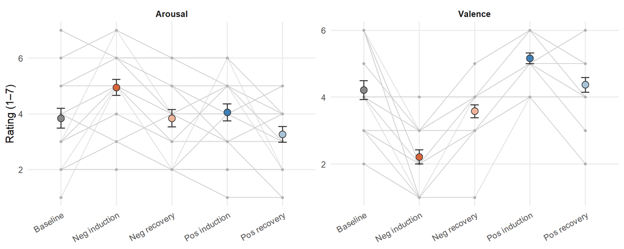

| Measure | N | Block effect | p | Neg ind - Baseline | Pos ind - Baseline | Pos ind - Neg ind |
| --- | --- | --- | --- | --- | --- | --- |
| Arousal | 19 | F(4, 72.0) = 8.28 | <.001 | +1.11 * | +0.21 | -0.89 * |
| Valence | 19 | F(4, 72.0) = 46.45 | <.001 | -2.00 * | +0.95 * | +2.95 * |

```r
show_note(ratings)
if (nrow(ratings)) { print(plot_blocks(ratings, ncol = 2, ylab = "Rating (1–7)")); print(kable(pretty_tests(test_table(ratings)))) }
```

### 2.2 Skin conductance (Ledalab CDA)

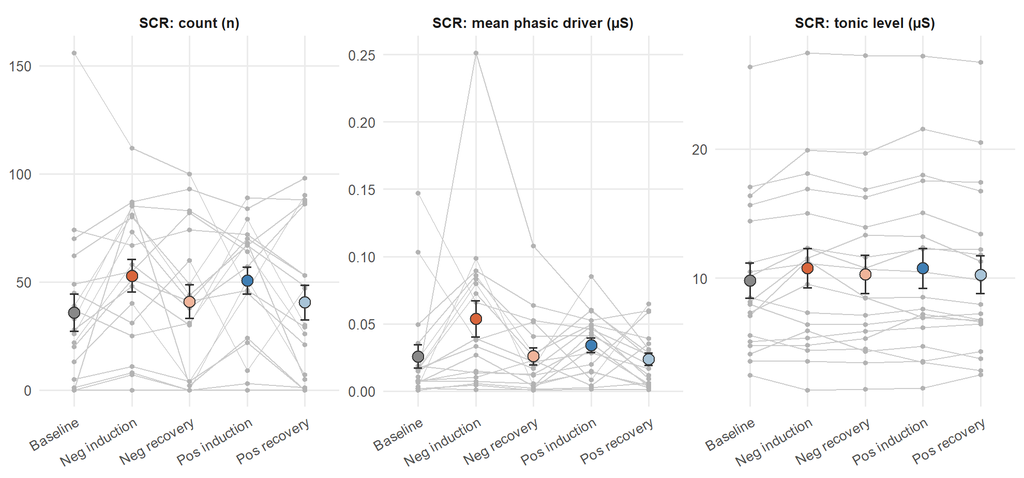

| Measure | N | Block effect | p | Neg ind - Baseline | Pos ind - Baseline | Pos ind - Neg ind |
| --- | --- | --- | --- | --- | --- | --- |
| SCR: count (n) | 19 | F(4, 72.0) = 2.60 | 0.043 | +17.11 * | +14.89 * | -2.21 |
| SCR: mean phasic driver (µS) | 19 | F(4, 72.0) = 3.27 | 0.016 | +0.03 * | +0.01 | -0.02 * |
| SCR: tonic level (µS) | 19 | F(4, 72.0) = 3.20 | 0.018 | +0.97 * | +0.95 * | -0.02 |

```r
show_note(scr)
if (nrow(scr)) { print(plot_blocks(scr)); print(kable(pretty_tests(test_table(scr)))) }
```

### 2.3 ECG heart rate and HRV (Kubios)

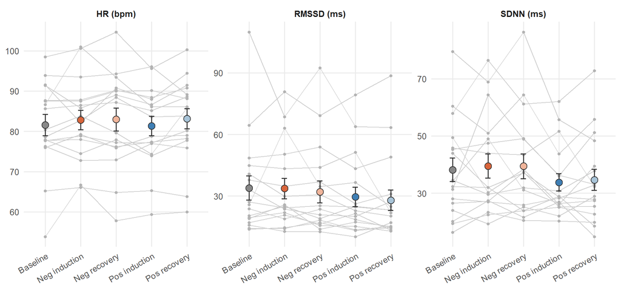

| Measure | N | Block effect | p | Neg ind - Baseline | Pos ind - Baseline | Pos ind - Neg ind |
| --- | --- | --- | --- | --- | --- | --- |
| HR (bpm) | 17 | F(4, 64.0) = 1.28 | 0.287 | +1.23 | -0.21 | -1.45 |
| RMSSD (ms) | 17 | F(4, 64.0) = 1.86 | 0.129 | -0.21 | -4.30 | -4.09 |
| SDNN (ms) | 17 | F(4, 64.0) = 2.28 | 0.071 | +1.31 | -4.40 | -5.71 * |

```r
show_note(ecg_hr)
if (nrow(ecg_hr)) { print(plot_blocks(ecg_hr)); print(kable(pretty_tests(test_table(ecg_hr)))) }
```

### 2.4 FaceReader heart rate and HRV (Kubios on FaceReader’s beats)

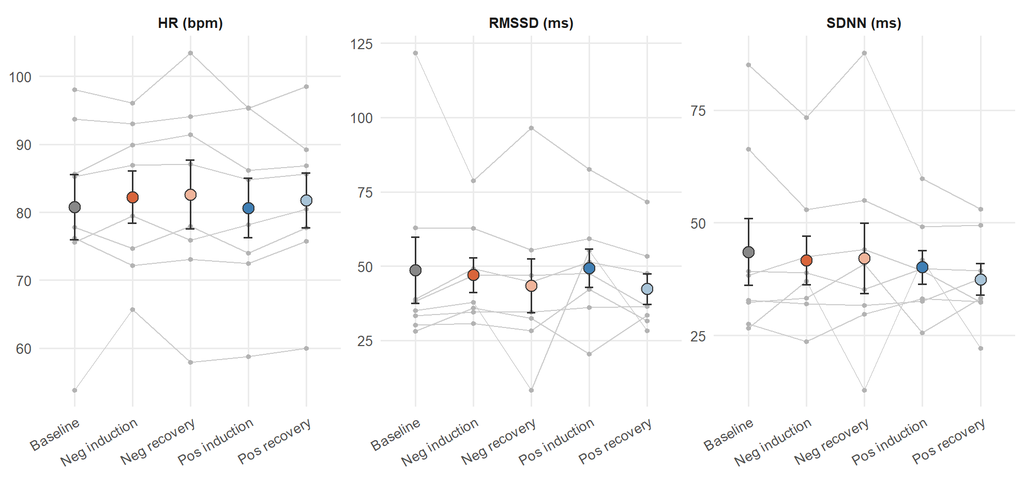

| Measure | N | Block effect | p | Neg ind - Baseline | Pos ind - Baseline | Pos ind - Neg ind |
| --- | --- | --- | --- | --- | --- | --- |
| HR (bpm) | 8 | F(4, 28.0) = 0.92 | 0.466 | +1.49 | -0.11 | -1.60 |
| RMSSD (ms) | 8 | F(4, 28.0) = 0.73 | 0.576 | -1.52 | +0.80 | +2.32 |
| SDNN (ms) | 8 | F(4, 28.0) = 0.67 | 0.616 | -1.85 | -3.41 | -1.56 |

```r
show_note(fr_hr)
if (nrow(fr_hr)) { print(plot_blocks(fr_hr)); print(kable(pretty_tests(test_table(fr_hr)))) }
```

### 2.5 FaceReader action units

Descriptive only: no statistical tests for the action units in this interim report. The heat map shows each AU’s mean intensity change from the participant’s own baseline (intensity scale 0–1), averaged across participants; the line plots show the key AUs per participant.

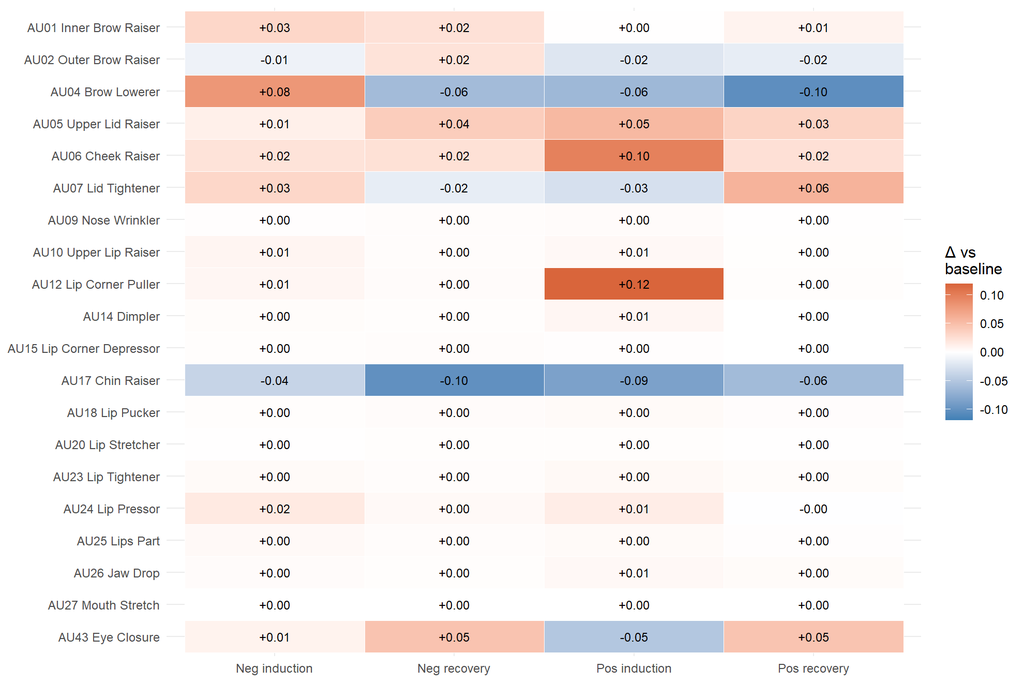

```r
show_note(aus)
if (nrow(aus)) {
  delta <- aus |> filter(!is.na(value)) |> group_by(pid, measure) |>
    mutate(d = value - value[block == "Baseline"][1]) |> ungroup() |>
    filter(block != "Baseline", !is.na(d)) |>
    group_by(measure, block) |> summarise(d = mean(d), .groups = "drop")
  lim <- max(abs(delta$d), 1e-6)
  print(ggplot(delta, aes(block, measure, fill = d)) + geom_tile(colour = "white") +
    geom_text(aes(label = sprintf("%+.02f", d)), size = 2.8) +
    scale_fill_gradient2(low = "#3F7FB5", mid = "white", high = "#D9653B", limits = c(-lim, lim),
                         name = "Δ vs\nbaseline") +
    scale_y_discrete(limits = rev) + labs(x = NULL, y = NULL) + theme_minimal(base_size = 10))
}
```

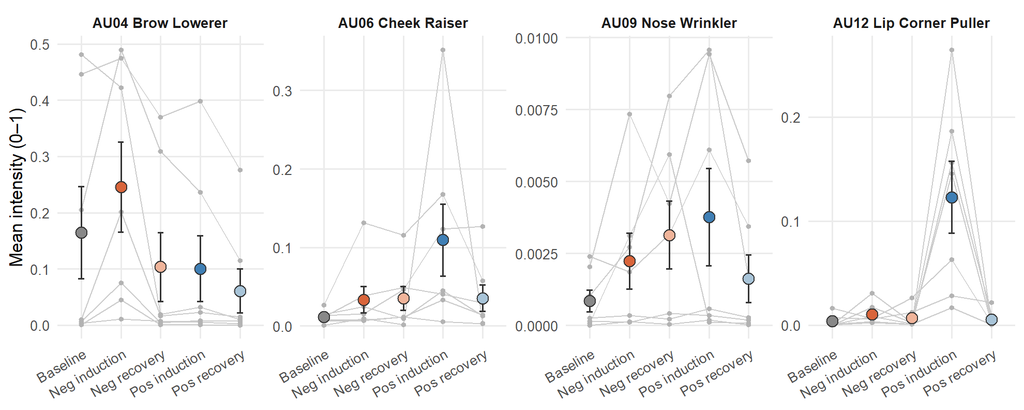

```r
if (nrow(aus)) {
  k <- aus |> filter(au %in% KEY_AUS)
  if (nrow(k)) print(plot_blocks(k, ncol = 4, ylab = "Mean intensity (0–1)"))
}
```

## 3. Do FaceReader and ECG agree?

Both sources were run through Kubios with the same five block windows (FaceReader’s on its own video clock) and the same artefact (noise) correction level (Medium), so these are the numbers each pipeline delivers as used. Agreement is assessed on one value per participant (the mean across blocks), so each participant counts once.

Agreement per measure, one value per participant (mean across blocks). CCC = Lin’s concordance (1 = identical values).

| Measure | Participants | ECG mean | FaceReader mean | Bias (FR − ECG) | 95% limits of agreement | Mean abs. difference | Mean abs. % difference | r | CCC |
| --- | --- | --- | --- | --- | --- | --- | --- | --- | --- |
| HR (bpm) | 8 | 82.41 | 81.61 | -0.79 | -2.6 to 1.1 | 0.83 | 0.95 | 1.00 | 1.00 |
| RMSSD (ms) | 8 | 30.92 | 46.14 | 15.22 | 5.4 to 25.1 | 15.22 | 73.15 | 0.98 | 0.78 |
| SDNN (ms) | 8 | 36.63 | 40.99 | 4.35 | 0.3 to 8.4 | 4.48 | 15.14 | 0.99 | 0.95 |

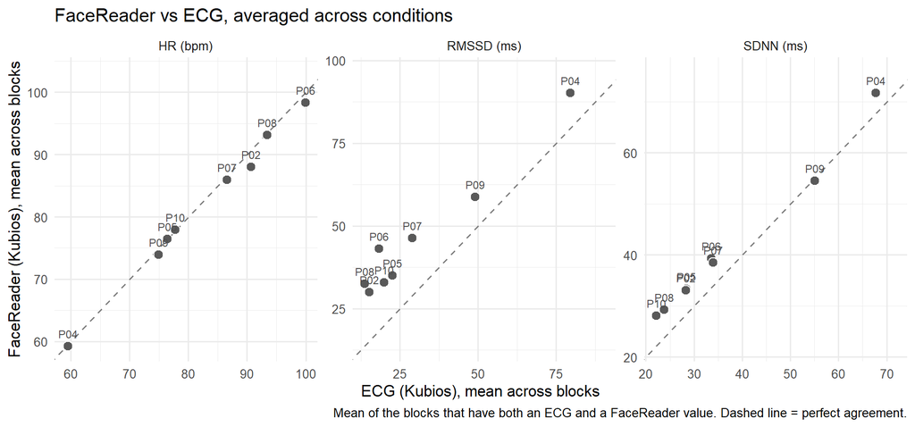

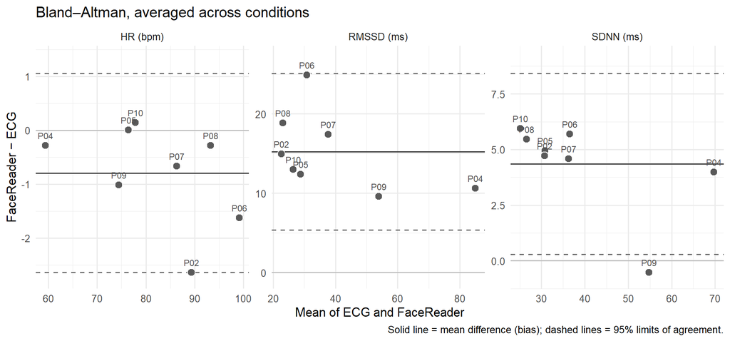

```r
if (!nrow(ecg_hr) || !nrow(fr_hr)) {
  cat("> **Not shown:** needs Kubios results for both the ECG and the FaceReader beats.\n")
} else {
  j <- inner_join(ecg_hr, fr_hr, by = c("pid", "block", "measure"), suffix = c("_ecg", "_fr")) |>
    filter(!is.na(value_ecg), !is.na(value_fr))
  if (!nrow(j)) { cat("> No participant × block has both an ECG and a FaceReader value yet.\n") } else {
    # One value per participant and source: the mean of the blocks that have both an ECG and a
    # FaceReader value (so both means cover the same blocks). Agreement statistics and the
    # Bland–Altman plot use these, so each participant counts once.
    pm <- j |> group_by(pid, measure) |>
      summarise(ecg = mean(value_ecg), fr = mean(value_fr), n_blocks = n(), .groups = "drop") |>
      mutate(Participant = pid_code[pid], diff = fr - ecg, avg = (fr + ecg) / 2)

    ccc <- function(x, y) 2 * cov(x, y) / (var(x) + var(y) + (mean(x) - mean(y))^2)
    ag <- pm |> group_by(measure) |> summarise(
      Participants = n(),
      `ECG mean` = mean(ecg), `FaceReader mean` = mean(fr),
      `Bias (FR − ECG)` = mean(diff),
      `95% limits of agreement` = if (n() >= 3) sprintf("%.1f to %.1f", mean(diff) - 1.96 * sd(diff), mean(diff) + 1.96 * sd(diff)) else "–",
      `Mean abs. difference` = mean(abs(diff)),
      `Mean abs. % difference` = 100 * mean(abs(diff) / ecg),
      r = if (n() >= 3) cor(ecg, fr) else NA_real_,
      CCC = if (n() >= 3) ccc(ecg, fr) else NA_real_, .groups = "drop") |>
      rename(Measure = measure)
    print(kable(ag, digits = 2, caption = paste(
      "Agreement per measure, one value per participant (mean across blocks).",
      "CCC = Lin's concordance (1 = identical values).")))

    lims <- pm |> group_by(measure) |> summarise(lo = min(ecg, fr), hi = max(ecg, fr), .groups = "drop")
    print(ggplot(pm, aes(ecg, fr)) +
      geom_blank(data = lims, aes(x = lo, y = lo)) + geom_blank(data = lims, aes(x = hi, y = hi)) +  # square-ish axes
      geom_abline(linetype = "dashed", colour = "grey50") +
      geom_point(shape = 21, size = 3, fill = "grey35", colour = "white") +
      geom_text(aes(label = Participant), size = 2.8, vjust = -1, colour = "grey30") +
      facet_wrap(~ measure, scales = "free") +
      scale_y_continuous(expand = expansion(mult = c(0.06, 0.14))) +   # room for the labels
      labs(x = "ECG (Kubios), mean across blocks", y = "FaceReader (Kubios), mean across blocks",
           title = "FaceReader vs ECG, averaged across conditions",
           caption = paste("Mean of the blocks that have both an ECG and a FaceReader value.",
                           "Dashed line = perfect agreement.")) +
      theme_minimal(base_size = 11))

    if (n_distinct(pm$pid) >= 3) {
      loa <- pm |> group_by(measure) |> summarise(b = mean(diff), lo = b - 1.96 * sd(diff), hi = b + 1.96 * sd(diff), .groups = "drop")
      print(ggplot(pm, aes(avg, diff)) +
        geom_hline(yintercept = 0, colour = "grey75") +
        geom_hline(data = loa, aes(yintercept = b), colour = "grey20") +
        geom_hline(data = loa, aes(yintercept = lo), linetype = "dashed", colour = "grey40") +
        geom_hline(data = loa, aes(yintercept = hi), linetype = "dashed", colour = "grey40") +
        geom_point(shape = 21, size = 3, fill = "grey35", colour = "white") +
        geom_text(aes(label = Participant), size = 2.8, vjust = -1, colour = "grey30") +
        facet_wrap(~ measure, scales = "free") +
        scale_y_continuous(expand = expansion(mult = c(0.08, 0.14))) +
        labs(x = "Mean of ECG and FaceReader", y = "FaceReader − ECG",
             title = "Bland–Altman, averaged across conditions",
             caption = "Solid line = mean difference (bias); dashed lines = 95% limits of agreement.") +
        theme_minimal(base_size = 11))
    }

    # Does FaceReader show the same block pattern as the ECG? Within-participant changes from baseline
    dj <- j |> group_by(pid, measure) |>
      mutate(d_ecg = value_ecg - value_ecg[block == "Baseline"][1], d_fr = value_fr - value_fr[block == "Baseline"][1]) |>
      ungroup() |> filter(block != "Baseline", !is.na(d_ecg), !is.na(d_fr))
    if (nrow(dj) >= 3) {
      cat("\n\nChange from baseline: do the two sources move together within a participant?\n\n")
      print(kable(dj |> group_by(Measure = measure) |>
        summarise(`Blocks` = n(), `r (change vs baseline)` = if (n() >= 3) cor(d_ecg, d_fr) else NA_real_,
                  `Same direction (%)` = 100 * mean(sign(d_ecg) == sign(d_fr)), .groups = "drop"), digits = 2))
    }
  }
}
```

Change from baseline: do the two sources move together within a participant?

| Measure | Blocks | r (change vs baseline) | Same direction (%) |
| --- | --- | --- | --- |
| HR (bpm) | 32 | 0.87 | 84.38 |
| RMSSD (ms) | 32 | 0.70 | 53.12 |
| SDNN (ms) | 32 | 0.72 | 71.88 |

With this few participants the limits of agreement are imprecise; they will narrow (or settle) as the sample grows.

# Exploratory: anxiety and depression scores

This part splits participants by their anxiety (GAD-7) and depression (PHQ-9) questionnaire scores, using the usual screening cut-offs (≥ 10 on GAD-7, ≥ 10 on PHQ-9, i.e. at least “moderate”), and shows the same measures as above for each group. With this few participants per group it is **purely descriptive: no statistical tests**, and a group of one or two people mostly shows those individuals. Participant codes are not shown in this part.

```r
quest <- safely_load({
  f <- file.path(get0("COMBINED_PSYCHO_DIR", ifnotfound = file.path(SERVER_ROOT, "clean_combined_data", "psychopy")),
                 "biosignals2_questionnaires_scored.csv")
  if (!file.exists(f)) stop("biosignals2_questionnaires_scored.csv not found (knit 04_questionnaire_analysis.Rmd)")
  read_csv(f, show_col_types = FALSE) |>
    transmute(pid = norm_pid(participant_id), gad7 = as.numeric(gad7_total), phq9 = as.numeric(phq9_total)) |>
    filter(!is.na(pid)) |> distinct(pid, .keep_all = TRUE) |>
    keep_pids()
}, "Questionnaires")

# Every block-level measure in the report, with the same names as the summary table
mood_measures <- bind_rows(
  ratings |> mutate(measure = paste("Self-report", tolower(measure))),
  scr,
  ecg_hr  |> mutate(measure = paste("ECG", measure)),
  fr_hr   |> mutate(measure = paste("FaceReader", measure)),
  if (nrow(aus)) aus |> filter(au %in% KEY_AUS) |> transmute(pid, block, measure = paste("FaceReader", measure), value)
) |> filter(!is.na(value)) |> select(pid, block, measure, value)
mood_order <- unique(mood_measures$measure)

mood_section <- function(score_col, cutoff, label) {
  if (!nrow(quest)) { cat("> **Not shown:** ", attr(quest, "note") %||% "no questionnaire scores yet.", "\n\n", sep = ""); return(invisible()) }
  q <- quest |> filter(!is.na(.data[[score_col]])) |>
    mutate(high = .data[[score_col]] >= cutoff)
  have <- intersect(q$pid, mood_measures$pid)
  q <- q |> filter(pid %in% have)
  n_hi <- sum(q$high); n_lo <- sum(!q$high)
  lo_lab <- sprintf("%s < %d (n = %d)", label, cutoff, n_lo)
  hi_lab <- sprintf("%s ≥ %d (n = %d)", label, cutoff, n_hi)
  cat(sprintf("Participants with a %s score and data in this report: %d (%d below the cut-off, %d at or above). %s scores range %g–%g.\n\n",
              label, nrow(q), n_lo, n_hi, label, min(q[[score_col]]), max(q[[score_col]])))
  if (n_hi == 0 || n_lo == 0) {
    cat(sprintf("> Everyone is %s the cut-off so far, so there are no groups to compare yet.\n\n",
                if (n_hi == 0) "below" else "at or above"))
    return(invisible())
  }
  d <- mood_measures |> inner_join(q |> select(pid, high), by = "pid") |>
    mutate(group = factor(ifelse(high, hi_lab, lo_lab), levels = c(lo_lab, hi_lab)),
           measure = factor(measure, levels = mood_order))
  s <- d |> group_by(measure, block, group) |>
    summarise(m = mean(value), se = sd(value) / sqrt(n()), n = n(), .groups = "drop")
  pd <- position_dodge(width = 0.3)
  print(ggplot(s, aes(block, m, colour = group, group = group)) +
    geom_line(position = pd, linewidth = 0.6) +
    geom_errorbar(aes(ymin = m - se, ymax = m + se), width = 0.2, position = pd, na.rm = TRUE) +
    geom_point(position = pd, size = 2.2) +
    scale_colour_manual(values = setNames(c("#3F7FB5", "#D9653B"), c(lo_lab, hi_lab)), name = NULL) +
    facet_wrap(~ measure, scales = "free_y", ncol = 4) +
    labs(x = NULL, y = NULL, title = paste("By", label, "group: block means ± 1 SE"),
         caption = "No error bar = only one participant in that group for that measure.") +
    theme_minimal(base_size = 10) +
    theme(axis.text.x = element_text(angle = 35, hjust = 1), legend.position = "top",
          strip.text = element_text(face = "bold", size = 8.5), panel.grid.minor = element_blank()))
  # Compact table: each group's mean across blocks, and its response to each induction
  tab <- d |> group_by(measure, group, pid) |>
    summarise(all = mean(value),
              neg = value[block == "Neg induction"][1] - value[block == "Baseline"][1],
              pos = value[block == "Pos induction"][1] - value[block == "Baseline"][1], .groups = "drop") |>
    group_by(measure, group) |>
    summarise(n = n(), all = mean(all), neg = mean(neg, na.rm = TRUE), pos = mean(pos, na.rm = TRUE), .groups = "drop") |>
    mutate(across(c(all, neg, pos), ~ ifelse(is.nan(.x), NA, .x)),
           txt = sprintf("%.2f | %+.2f | %+.2f", all, neg, pos), grp = ifelse(group == hi_lab, "high", "low")) |>
    select(measure, grp, txt) |> pivot_wider(names_from = grp, values_from = txt) |>
    arrange(measure)
  names(tab) <- c("Measure", setNames(c(lo_lab, hi_lab), c("low", "high"))[names(tab)[-1]])
  print(kable(tab, align = "lcc", caption = paste(
    "Group means: all blocks | negative induction − baseline | positive induction − baseline.",
    "Descriptive only.")))
}
```

## Anxiety (GAD-7)

```r
mood_section("gad7", GAD7_CUTOFF, "GAD-7")
```

Participants with a GAD-7 score and data in this report: 19 (15 below the cut-off, 4 at or above). GAD-7 scores range 1–18.

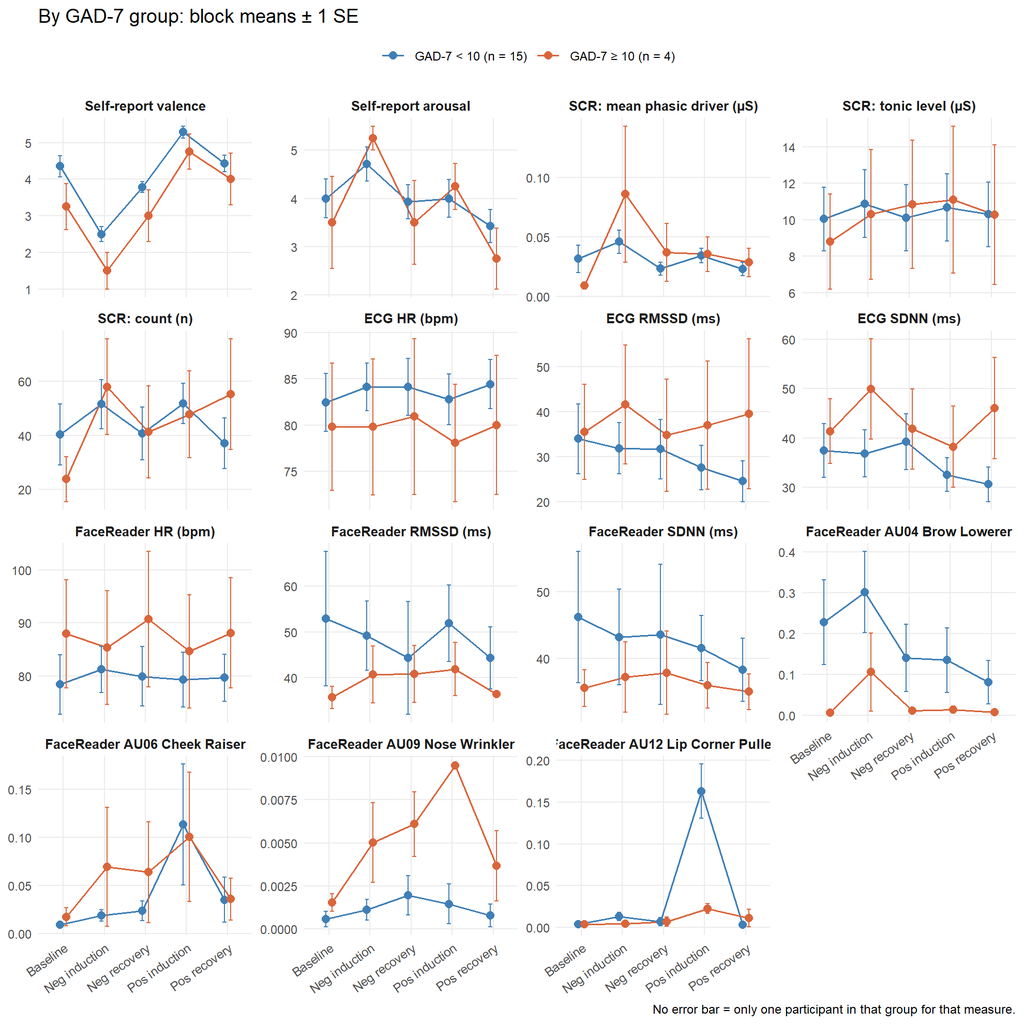

Group means: all blocks | negative induction − baseline | positive induction − baseline. Descriptive only.

| Measure | GAD-7 < 10 (n = 15) | GAD-7 ≥ 10 (n = 4) |
| --- | --- | --- |
| Self-report valence | 4.07 \| -1.86 \| +0.93 | 3.30 \| -1.75 \| +1.50 |
| Self-report arousal | 4.01 \| +0.71 \| +0.00 | 3.85 \| +1.75 \| +0.75 |
| SCR: mean phasic driver (µS) | 0.03 \| +0.01 \| +0.00 | 0.04 \| +0.08 \| +0.03 |
| SCR: tonic level (µS) | 10.41 \| +0.84 \| +0.63 | 10.27 \| +1.50 \| +2.30 |
| SCR: count (n) | 44.31 \| +11.21 \| +11.50 | 45.20 \| +34.25 \| +24.00 |
| ECG HR (bpm) | 83.59 \| +1.66 \| +0.34 | 79.72 \| -0.03 \| -1.77 |
| ECG RMSSD (ms) | 29.93 \| -2.11 \| -6.41 | 37.67 \| +6.13 \| +1.55 |
| ECG SDNN (ms) | 35.32 \| -0.61 \| -4.88 | 43.48 \| +8.63 \| -3.13 |
| FaceReader HR (bpm) | 79.70 \| +2.84 \| +0.95 | 87.36 \| -2.59 \| -3.29 |
| FaceReader RMSSD (ms) | 48.49 \| -3.70 \| -1.00 | 39.09 \| +5.02 \| +6.19 |
| FaceReader SDNN (ms) | 42.54 \| -3.01 \| -4.68 | 36.32 \| +1.65 \| +0.41 |
| FaceReader AU04 Brow Lowerer | 0.18 \| +0.07 \| -0.09 | 0.03 \| +0.10 \| +0.01 |
| FaceReader AU06 Cheek Raiser | 0.04 \| +0.01 \| +0.10 | 0.06 \| +0.05 \| +0.08 |
| FaceReader AU09 Nose Wrinkler | 0.00 \| +0.00 \| +0.00 | 0.01 \| +0.00 \| +0.01 |
| FaceReader AU12 Lip Corner Puller | 0.04 \| +0.01 \| +0.16 | 0.01 \| +0.00 \| +0.02 |

## Depression (PHQ-9)

```r
mood_section("phq9", PHQ9_CUTOFF, "PHQ-9")
```

Participants with a PHQ-9 score and data in this report: 19 (15 below the cut-off, 4 at or above). PHQ-9 scores range 1–18.

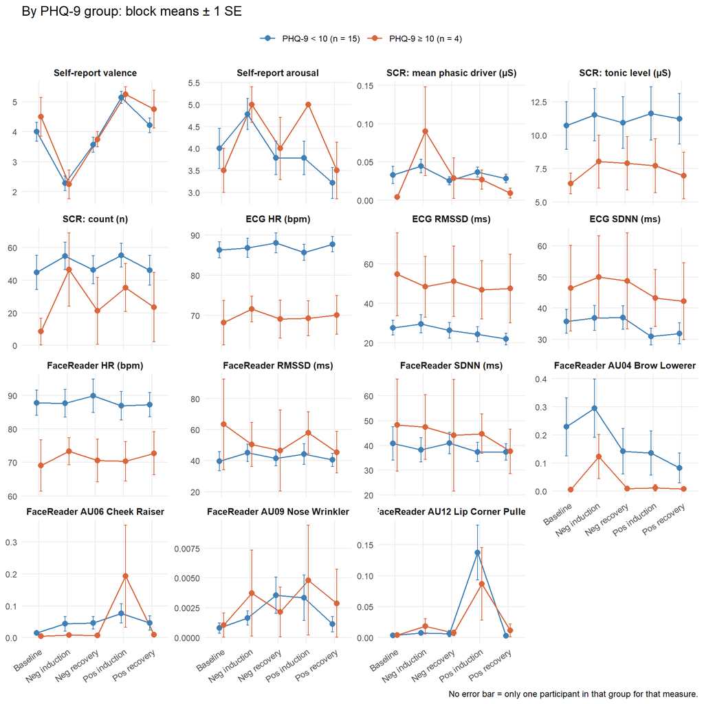

Group means: all blocks | negative induction − baseline | positive induction − baseline. Descriptive only.

| Measure | PHQ-9 < 10 (n = 15) | PHQ-9 ≥ 10 (n = 4) |
| --- | --- | --- |
| Self-report valence | 3.84 \| -1.71 \| +1.14 | 4.10 \| -2.25 \| +0.75 |
| Self-report arousal | 3.91 \| +0.79 \| -0.21 | 4.20 \| +1.50 \| +1.50 |
| SCR: mean phasic driver (µS) | 0.03 \| +0.01 \| +0.00 | 0.03 \| +0.09 \| +0.02 |
| SCR: tonic level (µS) | 11.22 \| +0.80 \| +0.91 | 7.41 \| +1.63 \| +1.32 |
| SCR: count (n) | 49.50 \| +10.14 \| +10.64 | 27.05 \| +38.00 \| +27.00 |
| ECG HR (bpm) | 86.93 \| +0.52 \| -0.63 | 69.70 \| +3.39 \| +1.12 |
| ECG RMSSD (ms) | 25.94 \| +2.04 \| -3.24 | 49.65 \| -6.32 \| -7.94 |
| ECG SDNN (ms) | 34.45 \| +1.09 \| -4.88 | 46.10 \| +3.54 \| -3.14 |
| FaceReader HR (bpm) | 87.86 \| -0.15 \| -0.93 | 71.20 \| +4.21 \| +1.25 |
| FaceReader RMSSD (ms) | 42.19 \| +5.39 \| +4.54 | 52.72 \| -13.04 \| -5.44 |
| FaceReader SDNN (ms) | 38.94 \| -2.52 \| -3.37 | 44.39 \| -0.74 \| -3.47 |
| FaceReader AU04 Brow Lowerer | 0.18 \| +0.07 \| -0.09 | 0.03 \| +0.12 \| +0.01 |
| FaceReader AU06 Cheek Raiser | 0.05 \| +0.03 \| +0.06 | 0.04 \| +0.00 \| +0.19 |
| FaceReader AU09 Nose Wrinkler | 0.00 \| +0.00 \| +0.00 | 0.00 \| +0.00 \| +0.00 |
| FaceReader AU12 Lip Corner Puller | 0.03 \| +0.00 \| +0.13 | 0.03 \| +0.01 \| +0.08 |

## Notes

- **Block-level ratings** are the state ratings given at the end of each block (baseline: after the 3-minute fixation), not the ratings of the individual videos.
- **SCR** is Ledalab continuous decomposition (CDA) over 0–180 s from each block onset: mean phasic driver, number of SCRs above 0.05 µS, and mean tonic level, from Ledalab’s event-related (ERA) export.
- **HR/HRV**: Kubios HRV Scientific on the BIOPAC ECG and, separately, on FaceReader’s heart beat log (1:1 lossless video of the webcam), with artefact (noise) correction set to Medium for both. FaceReader blocks with fewer than 10 beats are dropped.
- **Action units** are FaceReader intensities averaged over frames with a detected face, in the same windows as FaceReader HR/HRV. Blocks with a face in fewer than 50% of frames are dropped.
- **Anxiety and depression groups** use the GAD-7 and PHQ-9 totals from the questionnaire battery and the standard screening cut-offs (≥ 10 = at least moderate symptoms). These are screening scores, not diagnoses.
- Participants: main-study only; pilot, test and excluded sessions are set in `participant_status.csv`.